# Saudi Arabia

K.G.V.V. Bandara

7/5/2020

# **COVID-19 PANDEMIC IN SAUDI ARABIA**

## **1. Introduction**

### Visualization of the location

Saudi Arabia is a country situated in Southwest Asia. Saudi Arabia is bordered by Jordan and Iraq to the north, Kuwait to the northeast, Qatar, Bahrain, and the United Arab Emirates to the east, Oman to the southeast and Yemen to the south. It is separated from Egypt and Israel by the Gulf of Aqaba. The Saudi government estimate is at 2,217,949 square kilometres, while other reputable estimates vary between 2,149,690 and 2,240,000 sq. kilometres.

[figure not shown]

Saudi Arabia is bounded by seven countries and three bodies of water. To the west, the Gulf of Aqaba and the Red Sea form a coastal border of almost 1,800 km that extends to the southern part of Yemen and follows a mountain ridge for approximately 320 km to the vicinity of Najran.The country has a population of 31.7 million inhabitants, capital and largest city is Riyadh.

Saudi Arabia’s geography is dominated by the Arabian Desert, associated semi-desert and shrubland and several mountain ranges and highlands. It is, in fact, a number of linked deserts and includes the 647,500 km2 in the southeastern part of the country, the world’s largest contiguous sand desert.Though there are a few lakes in the country, Saudi Arabia is the largest country in the world by area with no permanent rivers. Wadis, however, are very numerous.The fertile areas are to be found in wadis, basins, and oasis alluvial deposits. The main topographic feature is the central plateau that rises abruptly from the Red Sea and descends gradually into the Nejd and towards the Persian Gulf. There is a narrow coastal plain along the Red Sea coast, known as the parallel Tihamah, to which an imposing escarpment runs. The southwest province of Asir is mountainous, and contains the 3,133 m Mount Sawda, which is the highest point in the country.

### Climate condition

In Saudi Arabia, the climate is generally desert, and it’s very hot in summer in all of the country. Nearly everywhere the rains are very low, and concentrated from November to April. Nonetheless, there are differences which are worth considering among the areas.The climate is desert along both the western and eastern coasts of Saudi Arabia, and it’s generally mild in winter, even warm in the central and southern part of the Red Sea coast, while it’s very hot everywhere in the summer, but it’s sultry on the Red Sea shores, and a little drier, and thus torrid, on the Persian Gulf shores.

With the exception of the province of Asir on the western coast, Saudi Arabia has a desert climate characterized by extreme heat during the day, an abrupt drop in temperature at night, and very low annual rainfall. Because of the influence of a subtropical high-pressure system, there is considerable variation in temperature and humidity. The two main differences in the climate of Saudi-Arabia can be felt between the coastal areas and the interior.

The average summer temperature is about 45° C, but readings of up to 54° C are not unusual. The heat becomes intense shortly after sunrise and lasts until sunset, followed by surprisingly cool nights. In the winter, the temperature seldom drops below 0° C, but the almost total absence of humidity and the high wind-chill factor make a quite cold atmosphere. In the spring and autumn the heat is temperate, temperatures average around 29° C. The area of Asir along the western coast is affected by monsoons from the Indian Ocean, which normally occur between October and March. In this time an total of 300 millimeters of rainfall occurs which is around 60 percent of the annual rainfall. Rainfall is very small, and intermittent for the rest of the world. The entire year’s rainfall may consist of one or two local, heavy cloudbursts or Thunderstorms.

### Lockdown status of the country

The World Healh Organization (WHO) verified on 12 January 2020 that a novel coronavirus is the source of a respiratory disease in a cluster of people in Whan City, Hubai Province , China, announced to the WHO on 31 December 2019. On 2 March 2020, the virus was reported to have reched from Saudi Arabia.

In early March, Saudi Arabia initially placed a temporary lockout on its eastern Qatif area, home to a significant Shia Muslim community, to avoid the spread of coronavirus, also known as COVID-19. Later, the unprecedented lockdown was extended to other parts of the country including Islam’s two holiest sites.

Ramadan is the holiest month for Muslims, in which they fast during daylight hours, congregate for prayers and share meals as a community. But because of coronavirus, almost all Muslim-majority countries have closed mosques and asked people to pray at home, in addition to imposing curfews to limit the spread of the deadly virus. A full lockdown was also imposed from May 23 to 27 during Eid al-Fitr. Saudi Arabia will start relaxing coronavirus restrictions lift the restrictions across the country, with the exception of the holy city of Mecca, from June 21. The round-the-clock curfew will remain in force in Mecca and is only expected to be reduced from June 21, when curfew time will be changed to 3pm-6am, and prayers will be allowed in mosques. Physical distancing guidelines are still required according to the government, while gatherings of over 50 people will remain prohibited. It will also allow some economic and commercial activities, including those at wholesale and retail stores, as well as shopping centers and cafés. But other establishments such as hair salons, barbershops, athletic and fitness clubs, recreation centres and movie theaters will stay closed due to the difficulties of enforcing physical distancing laws. In early March, Saudi Arabia initially placed a temporary lockout on its eastern Qatif area, home to a significant Shia Muslim community, to avoid the spread of coronavirus, also known as COVID-19.

### Actions taken by the government

The Kingdom of Saudi Arabia began taking precautionary actions before any cases occurred and before the WHO declared that COVID-19 was epidemic. This was due to the belief that starting earlier would prevent a sharp increase in the number of cases in Saudi Arabia and prevent COVID-19 from becoming an epidemic within the country. The Saudi Arabian actions can be categorized into two periods:

1. before the discovery of the first COVID-19 case
2. after the discovery of the first case of COVID-19.

Many precautionary actions were taken by the Saudi government.

- The first action was to set up a committee to determine and enforce the appropriate steps against COVID-19. This committee was composed of 19 departments and authorities. It has been called the “COVID-19 Follow-up Commission,” which is chaired by the Health Minister.
- The second action was to suspend entry into Saudi Arabia for Umrah; people were no longer allowed to visit the holy mosque in Makkah or the holy mosque in Almadinah.
- The third action involved ceasing to issue visas to individuals coming from countries that had already been affected by COVID-19 and in which an epidemic situation existed, This action was taken as cases began to occur in neighboring countries, especially among the Gulf countries for which a visa is not required to enter Saudi Arabia.
- The government barred citizens of the Gulf countries from entering the two holy cities. Furthermore, due to the increase in the number of COVID-19 cases among Gulf countries and because most of these cases occurred due to travel to Iran, which was an epidemic area with thousands of cases.
- The citizens of these countries were not allowed to enter Saudi Arabia with their national ID but only with their passport to ensure that they had not visited Iran in the previous weeks.
- The country stopped exporting all medical devices and products, including diagnostic agents or those used for protection, to ensure that these would be available in the event of COVID-19 cases, and twenty five hospitals all over Saudi Arabia were determined to address COVID-19 cases. Since the disease has no treatment, prevention is the best method of stopping the spread of the virus; therefore, massive campaigns were conducted by the Ministry of Health (MoH) and other agencies to educate the public on ways to prevent the spread of the virus.
- The individual was a citizen who had visited Iran through Bahrain. The patient did not follow the recommendations and orders of the government and did not declare that he had been in Iran. Many precautions and restrictions have been applied in Saudi Arabia. More actions were taken by the government, and there was coordination among the Gulf countries.
- The Saudi government notified other Gulf countries that they could apply the same precautions toward Saudi citizens. Other ministries have also started to apply precautions. One of the main ministries is the Ministry of Education, which developed a plan for universities and general education to limit the spread of the virus among students and employees. The MoH issued warning to any hospital that did not take precautions against COVID-19.
- People who came from Bahrain, Kuwait and the United Arab Emirates could only arrive by air and only from three cities: Riyadh, Jeddah and Dammam. For people wishing to visit Saudi Arabia, a laboratory certificate was required that confirmed through a polymerase chain reaction (PCR). Some areas of Saudi Arabia have more cases, such as Alqatif city; therefore, a city lockdown was performed, and all study and work in governmental and private sectors was stopped in Alqatif for starting on March 7th.
- The government of Saudi Arabia applied more rigorous restrictions because the number of cases was increasing rapidly worldwide and in Saudi Arabia. One of the most important actions was to suspend all in-person schools and universities in both governmental and private sectors across the country and utilize online teaching.
- The number of COVID-19 cases had increased in Saudi, specifically in Makkah and Almadinah; therefore, the two cities were locked down, and a 24-hour curfew was applied on April 2nd.
- Further restrictions were placed on 5 cities and 4 governorates to start a 24-hour curfew, and the curfew was changed to start at 3 pm instead of 7 pm in all regions in the country.

## **2. Data Exploratory**

First, coronavirus data of Saudi Arabia was collected from 2020.01.22 to 2020.05.12 as below.

```r
sa_corona <- coronavirus %>% filter(country == "Saudi Arabia")
sa_corona_new<-sa_corona %>%
separate(date,into=c("year","month","day"),sep="-")
sa_corona_new<-sa_corona_new %>%
  mutate(month=if_else(month=="01","Jan",
    if_else(month=="02","Feb",
      if_else(month=="03","Mar",
            if_else(month=="04","Apr","May"))
  )))
head(sa_corona_new)
```

```
  year month day province      country lat long      type cases
1 2020   Jan  22          Saudi Arabia  24   45 confirmed     0
2 2020   Jan  23          Saudi Arabia  24   45 confirmed     0
3 2020   Jan  24          Saudi Arabia  24   45 confirmed     0
4 2020   Jan  25          Saudi Arabia  24   45 confirmed     0
5 2020   Jan  26          Saudi Arabia  24   45 confirmed     0
6 2020   Jan  27          Saudi Arabia  24   45 confirmed     0
```

In the world map Saudi Arabia can be shown as below.

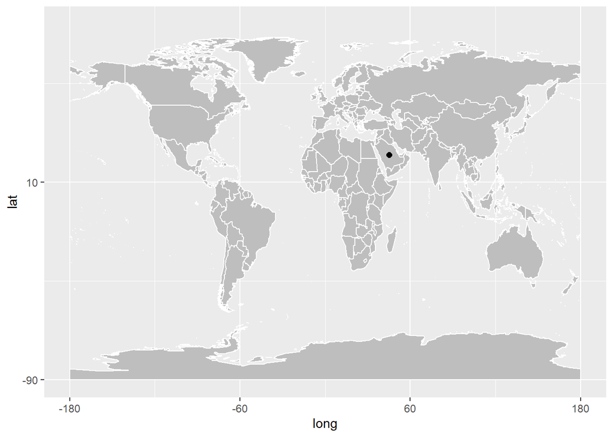

### Visualization of corona virus cases in Saudi Arabia

In here we analyzed the confirmed, death, recovered and active corona virus cases in Saudi Arabia using the data was collected from January to May.

#### Visualization of COVID-19 confirmed cases in Saudi Arabia

Represents the confirmed coronavirus cases in Saudi Arabia.

```r
confirmed_sa_corona<-sa_corona %>% filter(type=="confirmed")
head(confirmed_sa_corona)
```

```
        date province      country lat long      type cases
1 2020-01-22          Saudi Arabia  24   45 confirmed     0
2 2020-01-23          Saudi Arabia  24   45 confirmed     0
3 2020-01-24          Saudi Arabia  24   45 confirmed     0
4 2020-01-25          Saudi Arabia  24   45 confirmed     0
5 2020-01-26          Saudi Arabia  24   45 confirmed     0
6 2020-01-27          Saudi Arabia  24   45 confirmed     0
```

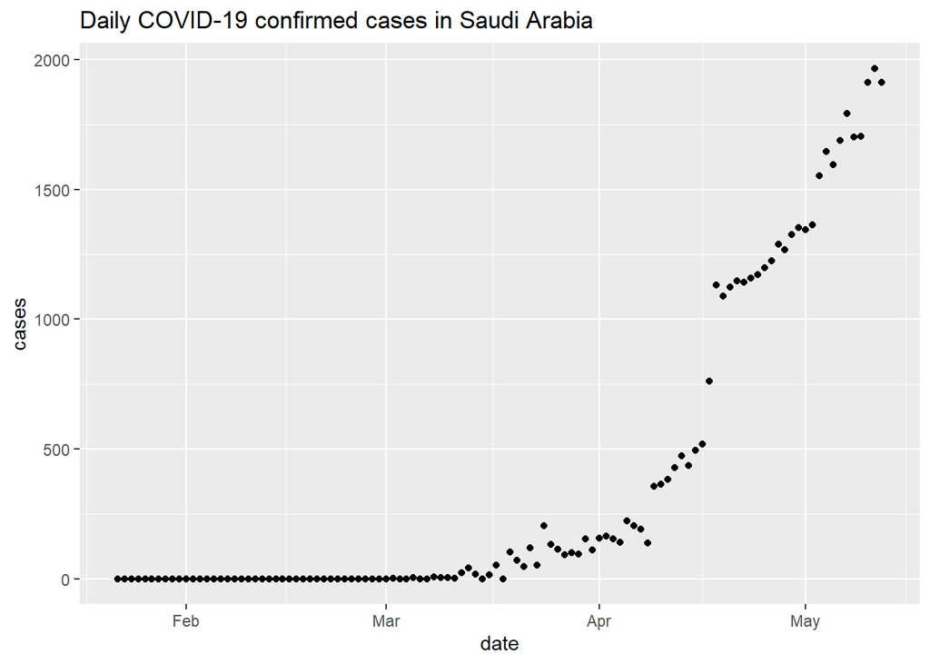

Figure 01: Daily COVID-19 confirmed cases in Saudi Arabia

The above figure shows the number of daily COVID-19 confirmed cases in Saudi Arabia from January to May. According to that there was no confirmed cases until mid of March. After that it was increased and the maximum number of confirmed cases reported on May.

#### Visualization of COVID-19 death cases in Saudi Arabia

Represents the daily death cases in Saudi Arabia.

```r
death_sa_corona<-sa_corona %>% filter(type=="death")
head(death_sa_corona)
```

```
        date province      country lat long  type cases
1 2020-01-22          Saudi Arabia  24   45 death     0
2 2020-01-23          Saudi Arabia  24   45 death     0
3 2020-01-24          Saudi Arabia  24   45 death     0
4 2020-01-25          Saudi Arabia  24   45 death     0
5 2020-01-26          Saudi Arabia  24   45 death     0
6 2020-01-27          Saudi Arabia  24   45 death     0
```

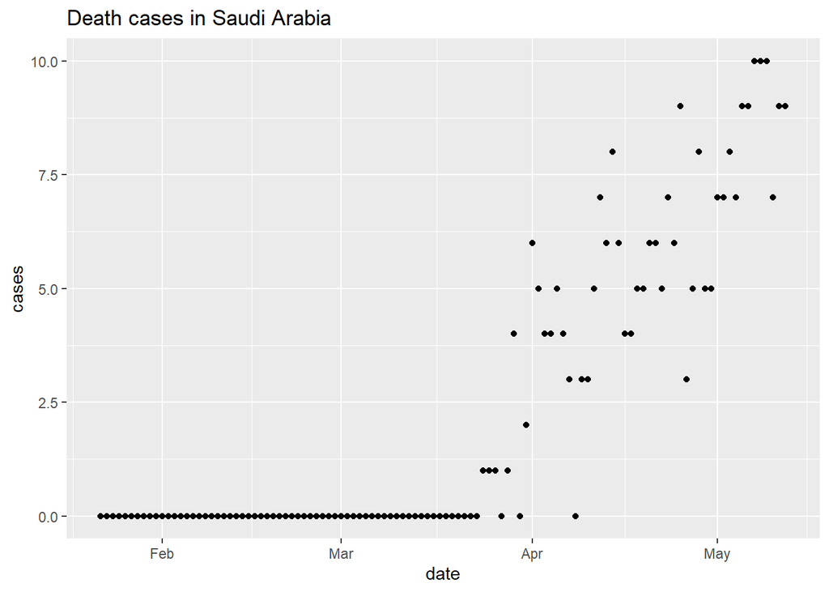

Figure 02: Daily COVID-19 death cases in Saudi Arabia

The above figure shows the number of daily COVID-19 death cases in Saudi Arabia from January to May. The first death case was found on third week of March. After that the death cases increased and the maximum number of death cases reported on May.

#### Visualization of recovered cases

Represents the recovered cases in Saudi Arabia.

```r
recovered_sa_corona<-sa_corona %>% filter(type=="recovered")
head(recovered_sa_corona)
```

```
        date province      country lat long      type cases
1 2020-01-22          Saudi Arabia  24   45 recovered     0
2 2020-01-23          Saudi Arabia  24   45 recovered     0
3 2020-01-24          Saudi Arabia  24   45 recovered     0
4 2020-01-25          Saudi Arabia  24   45 recovered     0
5 2020-01-26          Saudi Arabia  24   45 recovered     0
6 2020-01-27          Saudi Arabia  24   45 recovered     0
```

```r
summary(recovered_sa_corona)
```

```
      date              province           country               lat
 Min.   :2020-01-22   Length:112         Length:112         Min.   :24
 1st Qu.:2020-02-18   Class :character   Class :character   1st Qu.:24
 Median :2020-03-17   Mode  :character   Mode  :character   Median :24
 Mean   :2020-03-17                                         Mean   :24
 3rd Qu.:2020-04-14                                         3rd Qu.:24
 Max.   :2020-05-12                                         Max.   :24
      long        type               cases
 Min.   :45   Length:112         Min.   :   0.00
 1st Qu.:45   Class :character   1st Qu.:   0.00
 Median :45   Mode  :character   Median :   0.00
 Mean   :45                      Mean   : 136.22
 3rd Qu.:45                      3rd Qu.:  68.25
 Max.   :45                      Max.   :2520.00
```

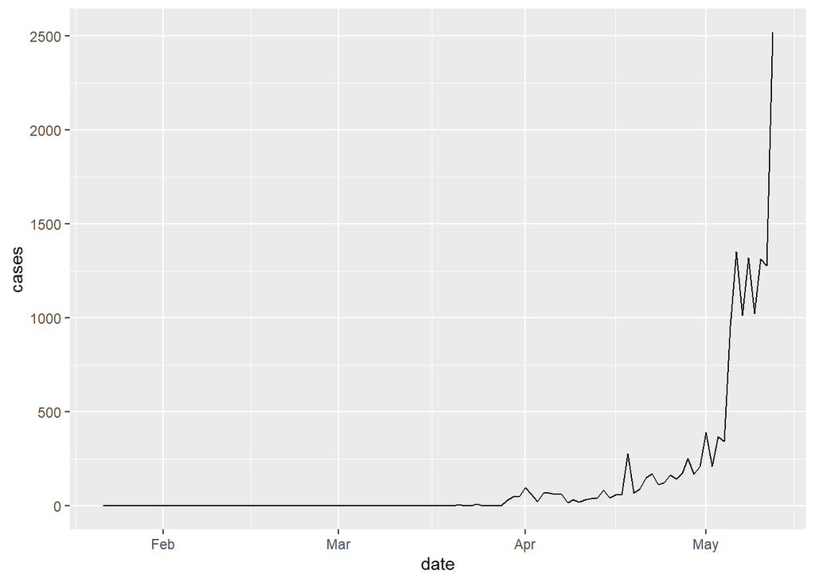

Figure 03:Time series plot in Saudi Arabi

The above figure shows the number of recovered cases in Saudi Arabia during the time period January and May.It shows that the number of daily recovered cases increased with the time. The maximum number of daily recovered cases reported on May.It was more than 2500.

#### Visualization of active COVID-19 cases in Saudi Arabia

```r
library(tidyr)
library(magrittr)
library(tidyverse)
sa_corona_newi <-sa_corona %>%
pivot_wider(names_from = type,values_from = cases)
sa_corona_newi
```

```
# A tibble: 112 x 8
   date       province country        lat  long confirmed death recovered
   <date>     <chr>    <chr>        <dbl> <dbl>     <int> <int>     <int>
 1 2020-01-22 ""       Saudi Arabia    24    45         0     0         0
 2 2020-01-23 ""       Saudi Arabia    24    45         0     0         0
 3 2020-01-24 ""       Saudi Arabia    24    45         0     0         0
 4 2020-01-25 ""       Saudi Arabia    24    45         0     0         0
 5 2020-01-26 ""       Saudi Arabia    24    45         0     0         0
 6 2020-01-27 ""       Saudi Arabia    24    45         0     0         0
 7 2020-01-28 ""       Saudi Arabia    24    45         0     0         0
 8 2020-01-29 ""       Saudi Arabia    24    45         0     0         0
 9 2020-01-30 ""       Saudi Arabia    24    45         0     0         0
10 2020-01-31 ""       Saudi Arabia    24    45         0     0         0
# ... with 102 more rows
```

```r
library(dplyr)
sa_corona_newii<- sa_corona_newi %>%
  mutate(active=confirmed-recovered-death)
sa_corona_newii
```

```
# A tibble: 112 x 9
   date       province country        lat  long confirmed death recovered active
   <date>     <chr>    <chr>        <dbl> <dbl>     <int> <int>     <int>  <int>
 1 2020-01-22 ""       Saudi Arabia    24    45         0     0         0      0
 2 2020-01-23 ""       Saudi Arabia    24    45         0     0         0      0
 3 2020-01-24 ""       Saudi Arabia    24    45         0     0         0      0
 4 2020-01-25 ""       Saudi Arabia    24    45         0     0         0      0
 5 2020-01-26 ""       Saudi Arabia    24    45         0     0         0      0
 6 2020-01-27 ""       Saudi Arabia    24    45         0     0         0      0
 7 2020-01-28 ""       Saudi Arabia    24    45         0     0         0      0
 8 2020-01-29 ""       Saudi Arabia    24    45         0     0         0      0
 9 2020-01-30 ""       Saudi Arabia    24    45         0     0         0      0
10 2020-01-31 ""       Saudi Arabia    24    45         0     0         0      0
# ... with 102 more rows
```

```r
library(dplyr)
sa_corona_newiii<-sa_corona_newii %>%
  mutate(active_total = cumsum(active),
                recovered_total = cumsum(recovered),
                death_total = cumsum(death))
sa_corona_newiii
```

```
# A tibble: 112 x 12
   date       province country   lat  long confirmed death recovered active
   <date>     <chr>    <chr>   <dbl> <dbl>     <int> <int>     <int>  <int>
 1 2020-01-22 ""       Saudi ~    24    45         0     0         0      0
 2 2020-01-23 ""       Saudi ~    24    45         0     0         0      0
 3 2020-01-24 ""       Saudi ~    24    45         0     0         0      0
 4 2020-01-25 ""       Saudi ~    24    45         0     0         0      0
 5 2020-01-26 ""       Saudi ~    24    45         0     0         0      0
 6 2020-01-27 ""       Saudi ~    24    45         0     0         0      0
 7 2020-01-28 ""       Saudi ~    24    45         0     0         0      0
 8 2020-01-29 ""       Saudi ~    24    45         0     0         0      0
 9 2020-01-30 ""       Saudi ~    24    45         0     0         0      0
10 2020-01-31 ""       Saudi ~    24    45         0     0         0      0
# ... with 102 more rows, and 3 more variables: active_total <int>,
#   recovered_total <int>, death_total <int>
```

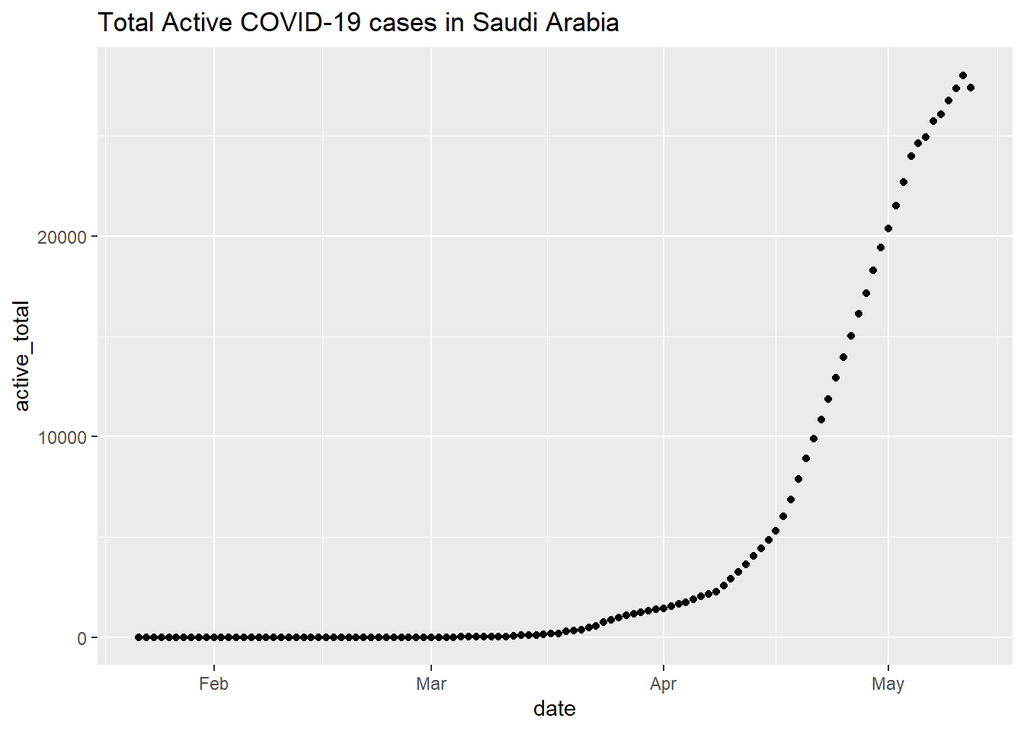

Figure 04: Total number of Active COVID-19 cases in Saudi Arabia

The confirmed, death and recovered COVID-19 cases in Saudi Arabi can be shown in a one graph.

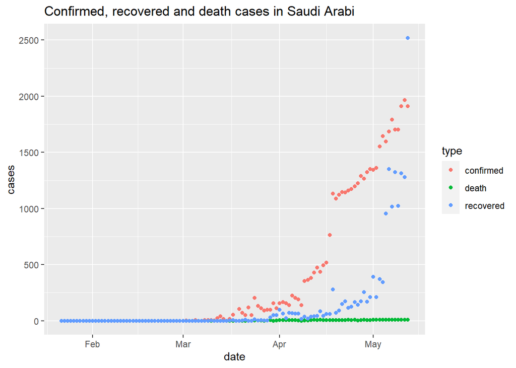

Figure 05: Daily COVID-19 confirmed, recovered and death cases in Saudi Arabi

According to that the daily confirmed and recovered cases are increased.

### Comparing the COVID-19 cases with other countries

Saudi Arabia is bordered by Jordan and Iraq to the north, Kuwait to the northeast, Qatar, Bahrain, and the United Arab Emirates to the east, Oman to the southeast and Yemen to the south. Egypt have as well maritime borders with Saudi Arabia in the east via the Red sea.

In this section , we compare Saudi Arabia’s corona virus cases to Egypt, Yemen, China and the US. Now we look how to counties are facing the corona virus.

#### Comparison of confirmed daily COVID-19 cases in Saudi Arabia with Egypt,Yemen, China and US

```r
corona_co <-filter(coronavirus,country %in% c( "Saudi Arabia","Egypt","Yemen","China","US"))
head(corona_co)
```

```
        date province country lat long      type cases
1 2020-01-22            Egypt  26   30 confirmed     0
2 2020-01-23            Egypt  26   30 confirmed     0
3 2020-01-24            Egypt  26   30 confirmed     0
4 2020-01-25            Egypt  26   30 confirmed     0
5 2020-01-26            Egypt  26   30 confirmed     0
6 2020-01-27            Egypt  26   30 confirmed     0
```

```r
conm_corona_co<-corona_co %>% filter(type=="confirmed")
head(conm_corona_co)
```

```
        date province country lat long      type cases
1 2020-01-22            Egypt  26   30 confirmed     0
2 2020-01-23            Egypt  26   30 confirmed     0
3 2020-01-24            Egypt  26   30 confirmed     0
4 2020-01-25            Egypt  26   30 confirmed     0
5 2020-01-26            Egypt  26   30 confirmed     0
6 2020-01-27            Egypt  26   30 confirmed     0
```

[figure not shown]

```r
library(ggplot2)
```

Figure 06:Daily COVID-19 confirmed cases in Saudi Arabia, Egypt,Yemen, China and US

Figure 06 shows that the confirmed cases of Saudi Arabia was quite increasing on April first week. But China hasn’t confirmed corona cases since March. US are started confrimed corona cases on mid of March. Most of confirmed country was US in that month peried. When comparing with Egypt and Yemen confirmed corona cases is lower than Saudi Arabia.

#### Comparison of daily COVID-19 death cases in Saudi Arabia with Egypt, Yemen, China and US

```r
death_corona_co<-corona_co %>% filter(type=="death")
head(death_corona_co)
```

```
        date province country lat long  type cases
1 2020-01-22            Egypt  26   30 death     0
2 2020-01-23            Egypt  26   30 death     0
3 2020-01-24            Egypt  26   30 death     0
4 2020-01-25            Egypt  26   30 death     0
5 2020-01-26            Egypt  26   30 death     0
6 2020-01-27            Egypt  26   30 death     0
```

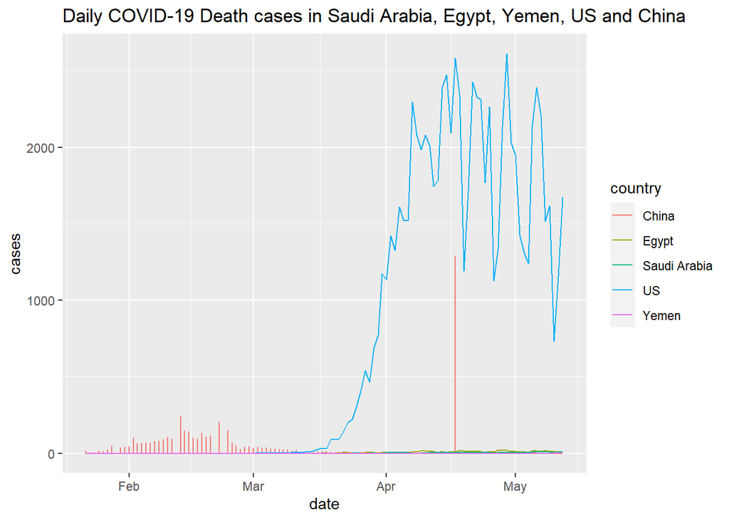

Figure 07: Daily COVID-19 death cases in Saudi Arabia, Egypt, Yemen, China and US

#### Comparison of daily recovered COVID-19 cases in Saudi Arabia with Egypt, Yemen, China and US

```r
recovered_corona_co<-corona_co %>% filter(type=="recovered")
head(recovered_corona_co)
```

```
        date province country lat long      type cases
1 2020-01-22            Egypt  26   30 recovered     0
2 2020-01-23            Egypt  26   30 recovered     0
3 2020-01-24            Egypt  26   30 recovered     0
4 2020-01-25            Egypt  26   30 recovered     0
5 2020-01-26            Egypt  26   30 recovered     0
6 2020-01-27            Egypt  26   30 recovered     0
```

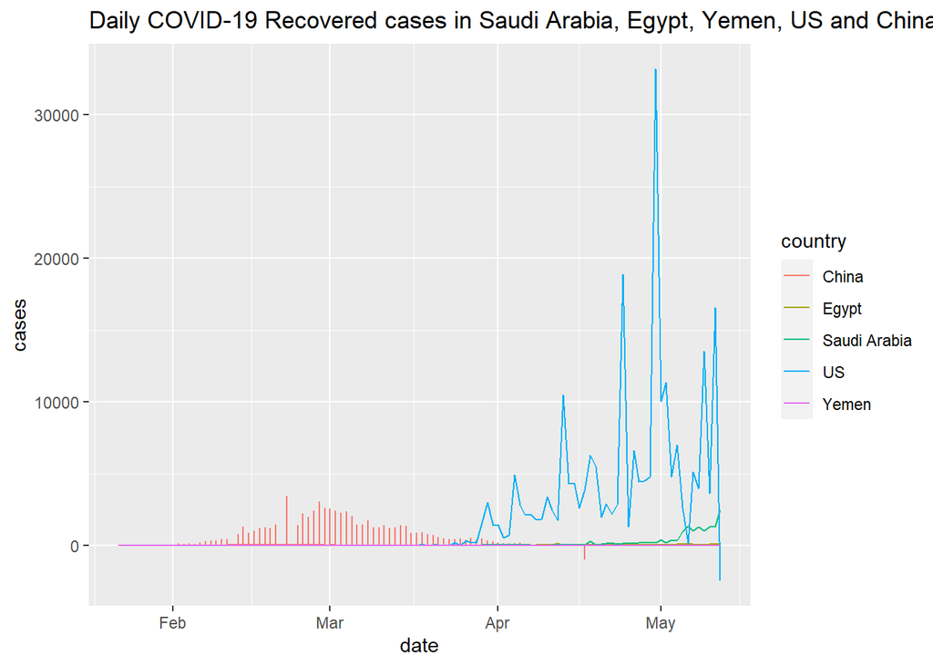

Figure 08:Daily COVID-19 recovered cases in Saudi Arabia, Egypt, Yemen, China and US

## **4.References**

- https://health.economictimes.indiatimes.com/news/industry/saudi-arabia-coronavirus-cases-exceed-100000/76251812
- https://www.aljazeera.com/news/2020/04/coronavirus-cases-saudi-arabia-reach-200000-minister-200407135834268.html
- https://www.cosmopolitanme.com/travel/everything-you-need-to-know-about-saudi-arabias-lockdown
- https://www.britannica.com/place/Saudi-Arabia
- https://en.wikipedia.org/wiki/COVID-19_pandemic_in_Saudi_Arabia
- https://www.britannica.com/place/Saudi-Arabia/Climate
- https://en.climate-data.org/asia/saudi-arabia-29/
- https://www.euronews.com/2020/03/27/saudi-arabia-clear-response-to-the-coronavirus-outbreak-is-in-stark-contrast-to-west-view
- https://www.sciencedirect.com/science/article/pii/S1319016420301080
- https://www.nytimes.com/2020/07/01/us/politics/coronavirus-us-embassy-saudi-arabia.html